# Explore Node Statistics

Preparation for network analysis in CCIEA ESR

M. Fisher

Written Jan 3, 2022. Last Run 2022-01-03

# Description

*based on “Explore Network Stats” script written Oct. 25, 2019 for Fisher et al.*

# Set up

This script requires the following packages.

```r
if(!require("tidyverse")) {install.packages("tidyverse")}
if(!require("ggplot2")) {install.packages("ggplot2")}
if(!require("gridExtra")) {install.packages("gridExtra")}
if(!require("cowplot")) {install.packages("cowplot")}
if(!require("PNWColors")) {devtools::install_github("jakelawler/PNWColors"); library(PNWColors)}
```

Select your directories.

```r
## directory with network statistics
indir <- 'results/statistics'

## directory to save figures
pngdir <- 'results/figures'
```

What are the names of the `.csv` files with the network statistics that you want to compare? Would not suggest listing more than 4. Files should all be in the input directory (`indir`) specified above.

```r
filenames <- c("VesselLevelNodeStats_2004_2020_21pcgroups_totalrev5000_indivrev500_connectivity_rmCrab_10pContribution.csv")

#"VesselLevelNetworkStats_2004_2020_21pcgroups_totalrev5000_indivrev500_connectivity_rmCrab_10pContribution.csv")
```

Specify which network metrics to retain from the full data set.

```r
node_metrics <- c('node_strength','eigen','deg_norm')
```

Specify which fisheries to retain from the full data set.

```r
myfisheries <- c('Shellfish', 'Echinoderms', 'Tuna', 'Non-DTS groundfish')
```

Specify which port groups to retain from the full data set.

```r
myports <- c("Fort Bragg", "Bodega Bay",  "San Francisco", "Morro Bay",
             "North WA Coast", "Puget Sound", "WA Coast","Astoria","Tillamook","Newport","Coos Bay")
```

# Data

Network metrics from different datasets.

```r
for(i in seq(1,length(filenames))){
  tmpdat <- read.csv(here::here(indir, filenames[i])) %>%
    dplyr::select(pcgroup, year, metier.cm, all_of(node_metrics)) %>%
    filter(pcgroup %in% myports)
  if(i==1){
    dat <- tmpdat
  } else{ dat <- bind_rows(dat,tmpdat)}
}

head(dat)
```

|  | pcgroup | year | metier.cm | node_strength | eigen | deg_norm |
| --- | --- | --- | --- | --- | --- | --- |
| 1 | Puget Sound | 2004 | Salmon | 0.087968924 | 0.038594406 | 0.3 |
| 2 | Puget Sound | 2004 | Crab | 0.401637198 | 0.270241710 | 0.8 |
| 3 | Puget Sound | 2004 | Tuna | 0.006201821 | 0.008508442 | 0.3 |
| 4 | Puget Sound | 2004 | Skate/dogfish/shark | 0.075882136 | 0.142457720 | 0.4 |
| 5 | Puget Sound | 2004 | Prawns/shrimp | 0.183383612 | 0.090704789 | 0.3 |
| 6 | Puget Sound | 2004 | Echinoderms | 0.011407765 | 0.005575632 | 0.2 |

Get node counts (network size) for each port group / year

```r
network_sizes <- dat %>%
  dplyr::select(pcgroup,year,metier.cm) %>%
  distinct() %>%
  group_by(pcgroup,year) %>%
  summarize(N=n())
```

Select only port groups / metiers of interest, them add on network size

```r
 dat <- dat %>%
    filter(metier.cm %in% myfisheries) %>%
  left_join(network_sizes, by=c("pcgroup","year"))
```

Check out the distributions of the metrics.

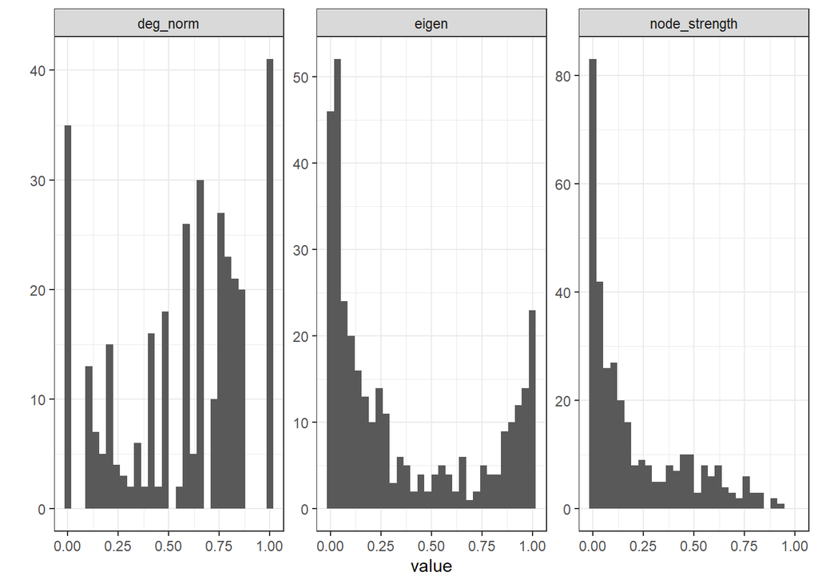

# Spearman Rank Correlation Test

```r
size_spearman <- function(mydata, metric){
  output <- data.frame(statistic = as.character(),
                       fishery = as.character(),
                       sp.rho = as.numeric(),
                       p.value = as.numeric())
    for(m in myfisheries){
      tmpdat <- filter(mydata, metier.cm==m)
      my.cor <- cor.test(tmpdat[,2], tmpdat[,3], method=("spearman"))
      output <- rbind(output,
                      data.frame(statistic=metric,fishery=m,sp.rho=my.cor$estimate,p.value=my.cor$p.value))
    }
  return(output)
}
```

### By fishery

Save an empty data frame

```r
spearman_dat <- data.frame(statistic = as.character(),
                           fishery = as.character(),
                           sp.rho = as.numeric(),
                           p.value = as.numeric())
```

Run Spearman Rank for each metric and append the output to the empty data frame.

```r
for(metric in node_metrics){
  tmpstats <- dat %>%
    dplyr::select(metier.cm, N, all_of(metric))
  tmp_out <- size_spearman(mydata=tmpstats,metric=metric)
  spearman_dat <- rbind(spearman_dat,
                        tmp_out)
}
```

[output not shown]

```r
spearman_dat <- spearman_dat %>%
  mutate(p.value.bonferroni=p.value*4) %>%
  pivot_longer(cols=c("p.value","p.value.bonferroni"), names_to="test_type",values_to="pval")
spearman_dat[which(spearman_dat$pval<0.05),]
```

| statistic | fishery | sp.rho | test_type | pval |
| --- | --- | --- | --- | --- |
| node_strength | Tuna | -0.4701177 | p.value | 6.752516e-10 |
| node_strength | Tuna | -0.4701177 | p.value.bonferroni | 2.701006e-09 |
| eigen | Shellfish | -0.6201643 | p.value | 1.038087e-02 |
| eigen | Shellfish | -0.6201643 | p.value.bonferroni | 4.152350e-02 |
| eigen | Echinoderms | -0.2757885 | p.value | 3.613130e-02 |
| eigen | Tuna | -0.4655608 | p.value | 1.034721e-09 |
| eigen | Tuna | -0.4655608 | p.value.bonferroni | 4.138884e-09 |
| deg_norm | Tuna | -0.4256572 | p.value | 3.362927e-08 |
| deg_norm | Tuna | -0.4256572 | p.value.bonferroni | 1.345171e-07 |

Results:

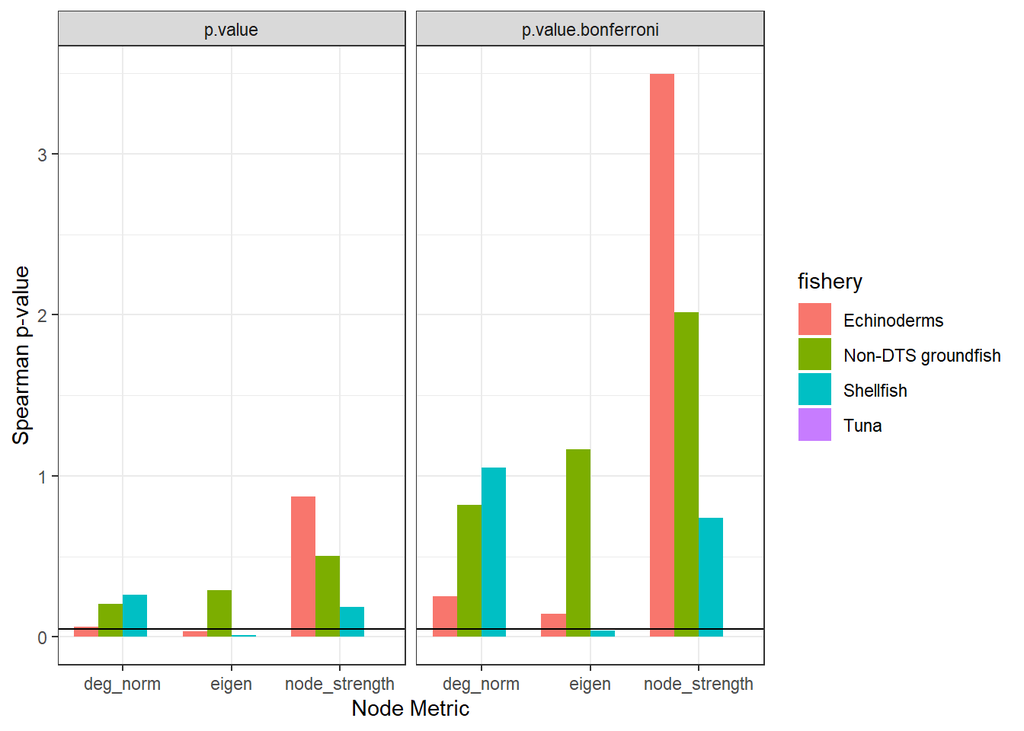

### Across fisheries

Save an empty data frame

```r
spearman_dat_all <- data.frame(statistic = as.character(),
                           fishery = as.character(),
                           sp.rho = as.numeric(),
                           p.value = as.numeric())
```

Run Spearman Rank for each metric and apply a Bonferroni correction– which are significant ($\alpha$=0.05)

```r
for(metric in node_metrics){
  tmpstats <- dat %>%
    dplyr::select(metier.cm, N, all_of(metric))
  my.cor <- cor.test(tmpstats[,2], tmpstats[,3], method=("spearman"))
  tmp_out <- data.frame(statistic=metric,sp.rho=my.cor$estimate,p.value=my.cor$p.value)
  spearman_dat_all <- rbind(spearman_dat_all,
                            tmp_out)
}
# apply correction
spearman_dat_all <- spearman_dat_all %>%
  mutate(p.value.bonferroni=p.value*3) %>%
  pivot_longer(cols=c("p.value","p.value.bonferroni"), names_to="test_type",values_to="pval")
spearman_dat_all[which(spearman_dat_all$pval<0.05),]
```

| statistic | sp.rho | test_type | pval |
| --- | --- | --- | --- |
| node_strength | -0.1245346 | p.value | 2.303502e-02 |
| eigen | -0.2450071 | p.value | 6.089025e-06 |
| eigen | -0.2450071 | p.value.bonferroni | 1.826707e-05 |
| deg_norm | -0.2209937 | p.value | 4.741829e-05 |
| deg_norm | -0.2209937 | p.value.bonferroni | 1.422549e-04 |

Results:

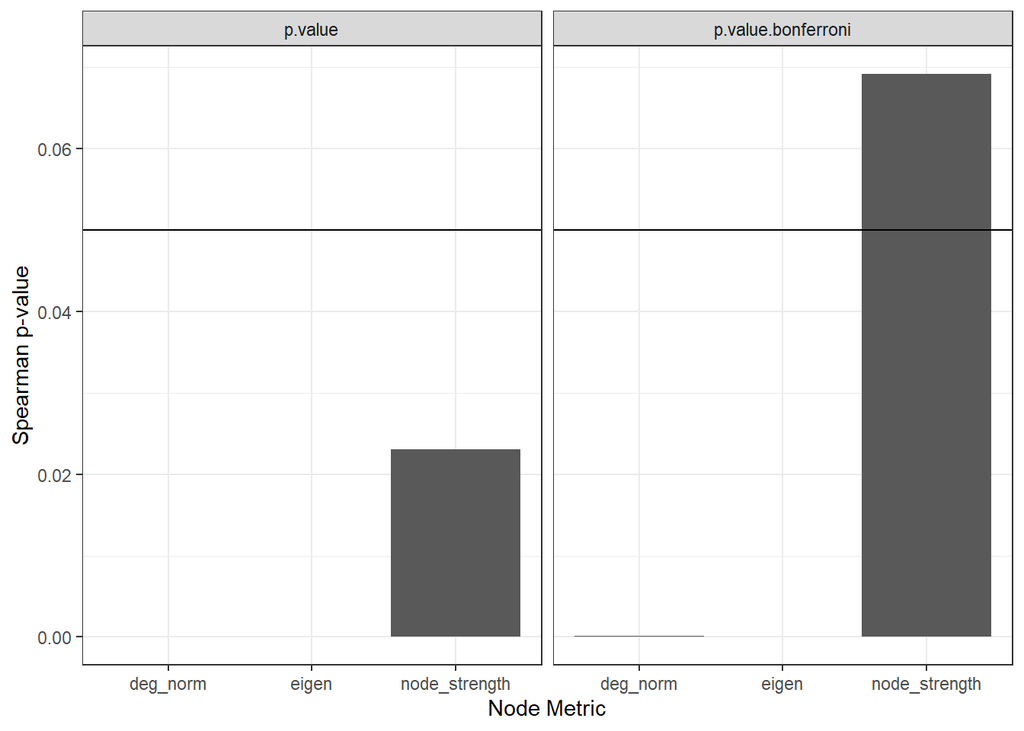